# DS4B

jshs

2023-03-18

# Primer modelo de machine learning predictivo

## Enfoque con un perfil de negocio.

- Se analizara desde la practica
- No habra mucha formula matematica, pero si se usaran algoritmos y se veran sus usos en la practica.
- Evidencia empirica.

## Preguntas validas para hacerse:

- ¿El por que de cada tecnica, cuando hay que aplicarla, como interpretar sus resultados, etc?
- El valor estaba en la parte practica.
- Saber lo que se quiere.

## A parte de machine learning predictivo (habilidad mas demandada) la ciencia de datos abarca:

- Analitica
- Machine learning
- Estadistica “profundizar en cartografia”
- Ciencias de computacion
- Comunicacion
- Matematicas
- Visualizacion
- IA
- Deep learning
- Ingenieria de datos

Claves: - Prevencion de abandono de clientes - campañas comerciales personalizadas para cada cliente - Scoring de riesgos - Identificacion de fraude - Mantenimiento preventivo

Nota: Simbolo tuerca y chunk output in console

### 0. Opciones generales:

```r
options(scipen=999) #desactiva la notacion cientifica. "El numero sale tal cual"
```

## 1. Instalamos y cargamos las librerias necesarias:

```r
#Instalar librerías
#install.packages('dplyr') #para manipular datos
#install.packages('skimr') #para exploración inicial
#install.packages('lubridate') #para manipular fechas
#install.packages('tidyr') #para manipular datos
#install.packages('ggplot2') #para hacer gráficos

#Cargar librerías
library(dplyr)
library(skimr)
library(lubridate)
library(tidyr)
library(ggplot2)
```

### CONTEXTO DEL NEGOCIO

Es un caso de mantenimiento preventivo, consiste en predecir con una serie de sensores y variables de cada maquina, cuando una maquina se va a estropiar o no y no esperar a que se dañe.

### Metodologias para la modelizacion avanzada de datos: (En este caso modo horizontal, cada fase tiene mas en vertical pero no se abarcaran en este proyecto)

- Importacion y muestreo
- Calidad de los datos
- Transformacion
- Modelizacion
- Evaluacion
- Implantacion

## 2. Cargamos los datos

```r
library(readr)
DataSetFallosMaquina <- read.csv("C:/Users/LAURA/Desktop/cursos data science/isaac_data_science/DataSetFallosMaquina.csv",
    sep = ";")
View(DataSetFallosMaquina)
```

## 3.Analisis inicial

```r
glimpse(DataSetFallosMaquina) #vision de todas las variables, tipo, numero de filas y numero de columnas
```

```
## Rows: 8,784
## Columns: 20
## $ Temperature                  <int> 67, 68, 64, 63, 65, 67, 67, 67, 65, 63, 6…
## $ Humidity                     <int> 82, 77, 76, 80, 81, 84, 83, 76, 80, 80, 8…
## $ Operator                     <chr> "Operator1", "Operator1", "Operator1", "O…
## $ Measure1                     <int> 291, 1180, 1406, 550, 1928, 398, 847, 102…
## $ Measure2                     <int> 1, 1, 1, 1, 1, 1, 0, 2, 2, 0, 2, 3, 0, 1,…
## $ Measure3                     <int> 1, 1, 1, 1, 2, 2, 2, 1, 0, 0, 2, 1, 0, 1,…
## $ Measure4                     <int> 1041, 1915, 511, 1754, 1326, 1901, 1849, …
## $ Measure5                     <int> 846, 1194, 1577, 1834, 1082, 1801, 1141, …
## $ Measure6                     <int> 334, 637, 1121, 1413, 233, 1153, 1609, 95…
## $ Measure7                     <int> 706, 1093, 1948, 1151, 1441, 1085, 982, 1…
## $ Measure8                     <int> 1086, 524, 1882, 945, 1736, 1547, 1159, 1…
## $ Measure9                     <int> 256, 919, 1301, 1312, 1033, 2005, 672, 42…
## $ Measure10                    <int> 1295, 245, 273, 1494, 1549, 477, 1128, 16…
## $ Measure11                    <int> 766, 403, 1927, 1755, 802, 1217, 663, 850…
## $ Measure12                    <int> 968, 723, 1123, 1434, 1819, 1632, 1114, 3…
## $ Measure13                    <int> 1185, 1446, 717, 502, 1616, 1324, 1838, 1…
## $ Measure14                    <int> 1355, 719, 1518, 1336, 1507, 1854, 290, 7…
## $ Measure15                    <int> 1842, 748, 1689, 711, 507, 1739, 1192, 84…
## $ Hours.Since.Previous.Failure <int> 90, 91, 92, 93, 94, 95, 96, 97, 98, 99, 1…
## $ Failure                      <chr> "No", "No", "No", "No", "No", "No", "No",…
```

```r
skim(DataSetFallosMaquina) #estadisticas basicas y grafica de distribucion de cada variable
```

Data summary

| Name | DataSetFallosMaquina |
| --- | --- |
| Number of rows | 8784 |
| Number of columns | 20 |
| _______________________ |  |
| Column type frequency: |  |
| character | 2 |
| numeric | 18 |
| ________________________ |  |
| Group variables | None |

**Variable type: character**

| skim_variable | n_missing | complete_rate | min | max | empty | n_unique | whitespace |
| --- | --- | --- | --- | --- | --- | --- | --- |
| Operator | 0 | 1 | 9 | 9 | 0 | 8 | 0 |
| Failure | 0 | 1 | 2 | 3 | 0 | 2 | 0 |

**Variable type: numeric**

| skim_variable | n_missing | complete_rate | mean | sd | p0 | p25 | p50 | p75 | p100 | hist |
| --- | --- | --- | --- | --- | --- | --- | --- | --- | --- | --- |
| Temperature | 0 | 1 | 64.03 | 2.87 | 5 | 62.00 | 64.0 | 66 | 78 | ▁▁▁▆▇ |
| Humidity | 0 | 1 | 83.34 | 4.84 | 65 | 80.00 | 83.0 | 87 | 122 | ▁▇▂▁▁ |
| Measure1 | 0 | 1 | 1090.90 | 537.10 | 155 | 629.00 | 1096.0 | 1555 | 2011 | ▇▇▇▇▇ |
| Measure2 | 0 | 1 | 1.49 | 1.12 | 0 | 0.00 | 1.0 | 2 | 3 | ▇▇▁▇▇ |
| Measure3 | 0 | 1 | 1.00 | 0.82 | 0 | 0.00 | 1.0 | 2 | 2 | ▇▁▇▁▇ |
| Measure4 | 0 | 1 | 1071.63 | 536.52 | 155 | 608.75 | 1058.0 | 1533 | 2011 | ▇▇▇▇▇ |
| Measure5 | 0 | 1 | 1075.82 | 533.16 | 155 | 606.00 | 1077.0 | 1541 | 2011 | ▇▇▇▇▇ |
| Measure6 | 0 | 1 | 1076.02 | 534.00 | 155 | 623.00 | 1072.0 | 1537 | 2011 | ▇▇▇▇▇ |
| Measure7 | 0 | 1 | 1086.90 | 538.20 | 155 | 621.00 | 1089.0 | 1558 | 2011 | ▇▇▇▇▇ |
| Measure8 | 0 | 1 | 1077.28 | 537.19 | 155 | 612.00 | 1074.0 | 1541 | 2011 | ▇▇▇▇▇ |
| Measure9 | 0 | 1 | 1082.01 | 532.98 | 155 | 631.00 | 1078.0 | 1532 | 2011 | ▇▇▇▇▇ |
| Measure10 | 0 | 1 | 1082.40 | 537.58 | 155 | 619.00 | 1080.0 | 1547 | 2011 | ▇▇▇▇▇ |
| Measure11 | 0 | 1 | 1088.72 | 535.00 | 155 | 627.00 | 1093.0 | 1550 | 2011 | ▇▇▇▇▇ |
| Measure12 | 0 | 1 | 1088.33 | 533.30 | 155 | 627.00 | 1082.0 | 1552 | 2011 | ▇▇▇▇▇ |
| Measure13 | 0 | 1 | 1076.76 | 535.11 | 155 | 609.00 | 1067.0 | 1539 | 2011 | ▇▇▇▇▇ |
| Measure14 | 0 | 1 | 1088.31 | 537.26 | 155 | 617.00 | 1088.5 | 1560 | 2011 | ▇▇▇▇▇ |
| Measure15 | 0 | 1 | 1082.39 | 537.53 | 155 | 614.00 | 1076.0 | 1550 | 2011 | ▇▇▇▇▇ |
| Hours.Since.Previous.Failure | 0 | 1 | 217.34 | 151.75 | 1 | 90.00 | 195.0 | 324 | 666 | ▇▆▅▂▁ |

```r
#knitr::kable(skim(DataSetFallosMaquina))
```

## 3.1 Analizamos en mayor detalle la temperatura

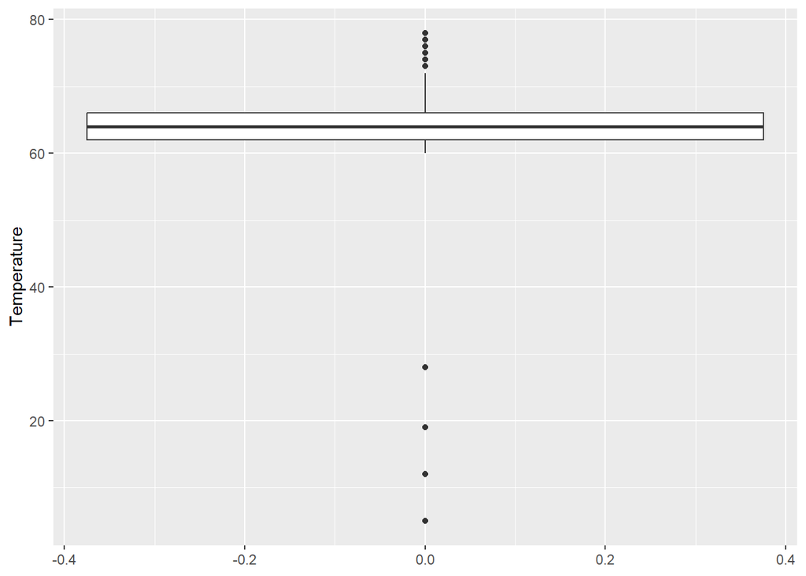

```r
attach(DataSetFallosMaquina)
ggplot(DataSetFallosMaquina,x=1) + geom_boxplot(aes(y=Temperature)) #tipo de grafico diagrama de cajas, distribucion llamada aes.
```

Nota: Se puede haber que hay cuatro datos que se estan saliendo de los rangos de temperatura

## 4.Calidad de datos

```r
#Corregimos los tipos de variables y los atípicos
#mutate para crear variables o para corregir las que tenemos.
# %>% ese simbolo es para encadenar instrucciones una de tras de otra, podemos hacer cuatro cosas seguidas e ir poniendo el simbolo

DataSetFallosMaquina <- DataSetFallosMaquina %>%
  mutate(Measure2 = as.factor(Measure2), #Corregimos Measure2
         Measure3 = as.factor(Measure3), #Corregimos Measure3
         Failure = as.factor(Failure), #estaba en caracter
         Operator = as.factor(Operator)) %>%  #estaba en caracter
  filter(Temperature > 50) #eliminamos los 4 atípicos de temperature
```